# Analyze ToothGrowth Dataset

York Huang

Sunday, March 13, 2016

## Overview

In the project, we’re going to analyze the ToothGrowth data in the R datasets package

## Prepare Data

Load data from R ToothGrowth package and convert to data frame.

```r
library(ggplot2)

data(ToothGrowth)
tg <- data.frame(ToothGrowth)
```

## Exploration Data

There are 60 observations.

```r
dim(tg)
```

```
## [1] 60  3
```

```r
head(tg)
```

```
##    len supp dose
## 1  4.2   VC  0.5
## 2 11.5   VC  0.5
## 3  7.3   VC  0.5
## 4  5.8   VC  0.5
## 5  6.4   VC  0.5
## 6 10.0   VC  0.5
```

Summary of data (tg) -

```r
summary(tg)
```

```
##       len        supp         dose
##  Min.   : 4.20   OJ:30   Min.   :0.500
##  1st Qu.:13.07   VC:30   1st Qu.:0.500
##  Median :19.25           Median :1.000
##  Mean   :18.81           Mean   :1.167
##  3rd Qu.:25.27           3rd Qu.:2.000
##  Max.   :33.90           Max.   :2.000
```

Plot tooth length vs supplement.

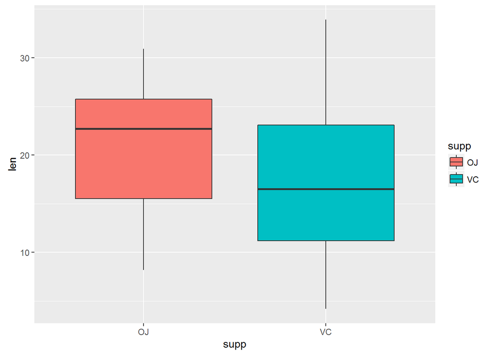

```r
ggplot(data=tg, aes(x=supp, y=len)) + geom_boxplot(aes(fill=supp))
```

Plot tooth length vs dose.

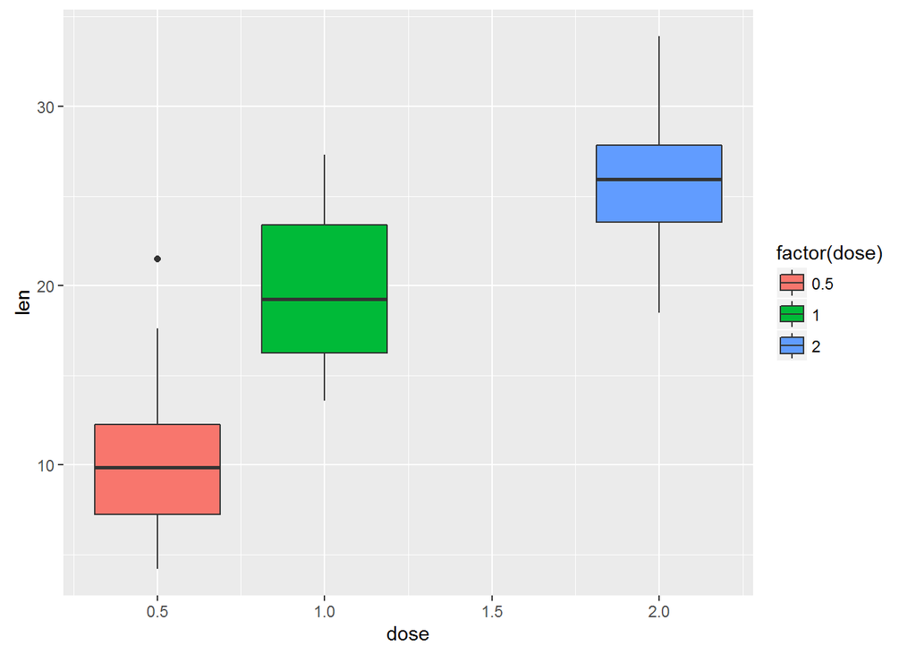

```r
ggplot(data=tg, aes(x=dose, y=len)) + geom_boxplot(aes(fill=factor(dose)))
```

## Use confidence intervals and/or hypothesis tests to compare tooth growth by supp and dose

Compare between supplements.

```r
t.test(tg$len[tg$supp=="OJ"], tg$len[tg$supp=="VC"], paired = FALSE, var.equal = FALSE)
```

```
##
##  Welch Two Sample t-test
##
## data:  tg$len[tg$supp == "OJ"] and tg$len[tg$supp == "VC"]
## t = 1.9153, df = 55.309, p-value = 0.06063
## alternative hypothesis: true difference in means is not equal to 0
## 95 percent confidence interval:
##  -0.1710156  7.5710156
## sample estimates:
## mean of x mean of y
##  20.66333  16.96333
```

The 95 percent confidence interval ( -0.1710156, 7.5710156) include 0. We are not conficent to compare the impacts between OJ and VC supplements.

Compare between dose 0.5 and 1.

```r
t.test(tg$len[tg$dose==0.5], tg$len[tg$dose==1], paired = FALSE, var.equal = FALSE)
```

```
##
##  Welch Two Sample t-test
##
## data:  tg$len[tg$dose == 0.5] and tg$len[tg$dose == 1]
## t = -6.4766, df = 37.986, p-value = 1.268e-07
## alternative hypothesis: true difference in means is not equal to 0
## 95 percent confidence interval:
##  -11.983781  -6.276219
## sample estimates:
## mean of x mean of y
##    10.605    19.735
```

The 95 percent confidence interval ( -11.983781, -6.276219) does NOT include 0. We are conficent to say it is helpful to tooth length when increasing does from 0.5 to 1.

Compare between dose 1 and 2.

```r
t.test(tg$len[tg$dose==1], tg$len[tg$dose==2], paired = FALSE, var.equal = FALSE)
```

```
##
##  Welch Two Sample t-test
##
## data:  tg$len[tg$dose == 1] and tg$len[tg$dose == 2]
## t = -4.9005, df = 37.101, p-value = 1.906e-05
## alternative hypothesis: true difference in means is not equal to 0
## 95 percent confidence interval:
##  -8.996481 -3.733519
## sample estimates:
## mean of x mean of y
##    19.735    26.100
```

The 95 percent confidence interval ( -8.996481, -3.733519) does NOT include 0. We are conficent to say it is helpful to tooth length when increasing does from 1 to 2.

## State your conclusions and the assumptions needed for your conclusions

We can summarize the following. 1. We can’t find the impact of supplements on tooth length. 2. Increasing dose is helpful to tooth length.

We also note that the observation size is still small. More data may help us better understand the impacts.